# Practical Machine Learning Course Project

Joel Varela Donado

4/12/2020

## Introduction and Background

This is the course project for Practical Machine Learning. It will predict how well a user is doing exercises, with data from the accelerometers on the belt, forearm, arm, and dumbbell of 6 participants. They were asked to perform the exercise of barbell lifts incorrectly in 5 different ways. More information: http://web.archive.org/web/20161224072740/http:/groupware.les.inf.puc-rio.br/har This report describes how a machine learning algorithm was developed, tested, and picked to be used to predict the outcome.

### Loading, Inspecting, Cleaning Data

```r
# Starting by reading the training file and loading the library
training=read.csv("pml-training.csv")
testing=read.csv("pml-testing.csv")
library(caret)
str(training)
```

```
## 'data.frame':    19622 obs. of  160 variables:
##  $ X                       : int  1 2 3 4 5 6 7 8 9 10 ...
##  $ user_name               : Factor w/ 6 levels "adelmo","carlitos",..: 2 2 2 2 2 2 2 2 2 2 ...
##  $ raw_timestamp_part_1    : int  1323084231 1323084231 1323084231 1323084232 1323084232 1323084232 1323084232 1323084232 1323084232 1323084232 ...
##  $ raw_timestamp_part_2    : int  788290 808298 820366 120339 196328 304277 368296 440390 484323 484434 ...
##  $ cvtd_timestamp          : Factor w/ 20 levels "02/12/2011 13:32",..: 9 9 9 9 9 9 9 9 9 9 ...
##  $ new_window              : Factor w/ 2 levels "no","yes": 1 1 1 1 1 1 1 1 1 1 ...
##  $ num_window              : int  11 11 11 12 12 12 12 12 12 12 ...
##  $ roll_belt               : num  1.41 1.41 1.42 1.48 1.48 1.45 1.42 1.42 1.43 1.45 ...
##  $ pitch_belt              : num  8.07 8.07 8.07 8.05 8.07 8.06 8.09 8.13 8.16 8.17 ...
##  $ yaw_belt                : num  -94.4 -94.4 -94.4 -94.4 -94.4 -94.4 -94.4 -94.4 -94.4 -94.4 ...
##  $ total_accel_belt        : int  3 3 3 3 3 3 3 3 3 3 ...
##  $ kurtosis_roll_belt      : Factor w/ 397 levels "","-0.016850",..: 1 1 1 1 1 1 1 1 1 1 ...
##  $ kurtosis_picth_belt     : Factor w/ 317 levels "","-0.021887",..: 1 1 1 1 1 1 1 1 1 1 ...
##  $ kurtosis_yaw_belt       : Factor w/ 2 levels "","#DIV/0!": 1 1 1 1 1 1 1 1 1 1 ...
```

[output cut: 86 more lines]

There are variables with lots of NAs and some that are clearly not needed for example user names and X (line number). Therefore we proceed to clean them from the data set.

```r
# Removing names, X, timestamps and windows.
filterRegEx = "timestamp|window"
training$user_name = NULL
training$X = NULL
training=training[, -grep(filterRegEx, names(training))]

testing$user_name = NULL
testing$X = NULL
testing=testing[, -grep(filterRegEx, names(testing))]

# There are variables with a lot of NAs. If the vast majority of column values (> 95%) is
# NA or empty then we exclude it from the study.

rmvMajorityNAs = function(x) {
    indexToRemove = c()
    for (i in 1:length(x)) {
        if (mean(is.na(x[,i]) || x[,i] =="") > 0.95) {
            indexToRemove = c(indexToRemove, i)
        }
    }
    x=x[,-indexToRemove]
}

training=rmvMajorityNAs(training)
testing=rmvMajorityNAs(testing)
str(training)
```

```
## 'data.frame':    19622 obs. of  53 variables:
##  $ roll_belt           : num  1.41 1.41 1.42 1.48 1.48 1.45 1.42 1.42 1.43 1.45 ...
##  $ pitch_belt          : num  8.07 8.07 8.07 8.05 8.07 8.06 8.09 8.13 8.16 8.17 ...
##  $ yaw_belt            : num  -94.4 -94.4 -94.4 -94.4 -94.4 -94.4 -94.4 -94.4 -94.4 -94.4 ...
##  $ total_accel_belt    : int  3 3 3 3 3 3 3 3 3 3 ...
##  $ gyros_belt_x        : num  0 0.02 0 0.02 0.02 0.02 0.02 0.02 0.02 0.03 ...
##  $ gyros_belt_y        : num  0 0 0 0 0.02 0 0 0 0 0 ...
##  $ gyros_belt_z        : num  -0.02 -0.02 -0.02 -0.03 -0.02 -0.02 -0.02 -0.02 -0.02 0 ...
##  $ accel_belt_x        : int  -21 -22 -20 -22 -21 -21 -22 -22 -20 -21 ...
##  $ accel_belt_y        : int  4 4 5 3 2 4 3 4 2 4 ...
##  $ accel_belt_z        : int  22 22 23 21 24 21 21 21 24 22 ...
##  $ magnet_belt_x       : int  -3 -7 -2 -6 -6 0 -4 -2 1 -3 ...
##  $ magnet_belt_y       : int  599 608 600 604 600 603 599 603 602 609 ...
##  $ magnet_belt_z       : int  -313 -311 -305 -310 -302 -312 -311 -313 -312 -308 ...
##  $ roll_arm            : num  -128 -128 -128 -128 -128 -128 -128 -128 -128 -128 ...
```

[output cut: 39 more lines]

The above shows the final number of variables. The same operation was performed on the official testing set for the Course.

## Starting the training model

We will setup two models with Random Forest and Gradient Boosting, and compare their accuracy. Will divide the training set to 70% of training and 30% of test validation.

```r
set.seed(412)
inTrain=createDataPartition(y=training$classe, p=0.7, list=FALSE)
trainingMain = training[inTrain, ]
trainingTestVal = training[-inTrain, ]
```

Now that we have split our training set, we are creating the models.

### First Model: Random Forest

```r
RFModel = train(classe ~., data=trainingMain, method="rf")
RFModel
```

```
## Random Forest
##
## 13737 samples
##    52 predictor
##     5 classes: 'A', 'B', 'C', 'D', 'E'
##
## No pre-processing
## Resampling: Bootstrapped (25 reps)
## Summary of sample sizes: 13737, 13737, 13737, 13737, 13737, 13737, ...
## Resampling results across tuning parameters:
##
##   mtry  Accuracy   Kappa
##    2    0.9888454  0.9858942
##   27    0.9895881  0.9868331
##   52    0.9831108  0.9786427
##
## Accuracy was used to select the optimal model using the largest value.
## The final value used for the model was mtry = 27.
```

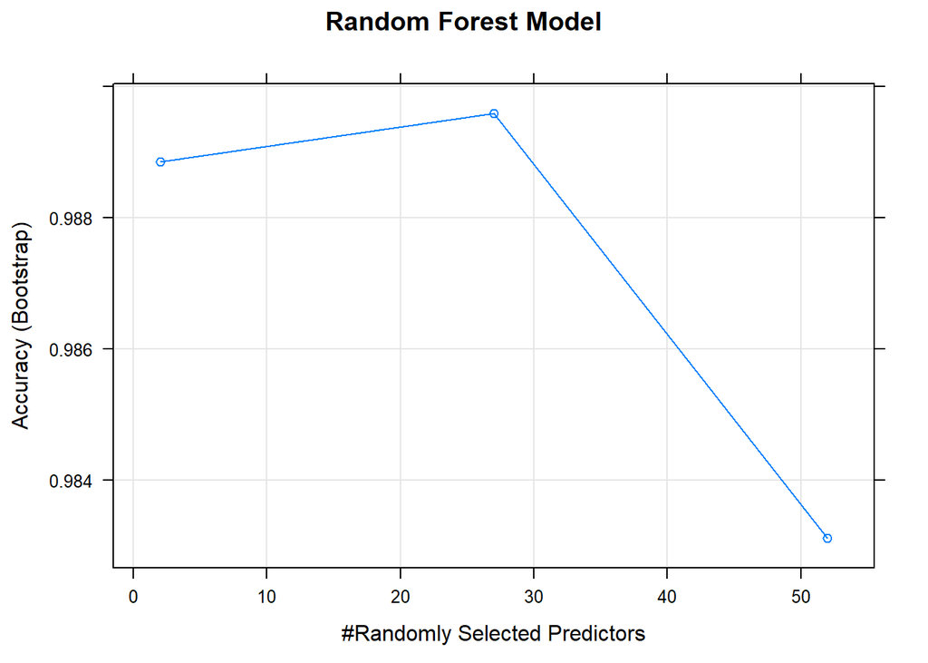

```r
plot(RFModel, main="Random Forest Model")
```

The model’s overall accuracy is 0.989 with 27 variables. We’ll test with the out-of-sample set from the training data.

```r
# Testing the Random Forest with the out-of-sample test set
predictTestVal = predict(RFModel, trainingTestVal)
cmRFTraining = confusionMatrix(trainingTestVal$classe, predictTestVal)
cmRFTraining
```

```
## Confusion Matrix and Statistics
##
##           Reference
## Prediction    A    B    C    D    E
##          A 1673    0    0    0    1
##          B    8 1125    5    1    0
##          C    0    7 1014    5    0
##          D    0    1   10  953    0
##          E    0    0    1    0 1081
##
## Overall Statistics
##
##                Accuracy : 0.9934
##                  95% CI : (0.991, 0.9953)
##     No Information Rate : 0.2856
##     P-Value [Acc > NIR] : < 2.2e-16
##
##                   Kappa : 0.9916
##
##  Mcnemar's Test P-Value : NA
##
## Statistics by Class:
##
##                      Class: A Class: B Class: C Class: D Class: E
## Sensitivity            0.9952   0.9929   0.9845   0.9937   0.9991
## Specificity            0.9998   0.9971   0.9975   0.9978   0.9998
## Pos Pred Value         0.9994   0.9877   0.9883   0.9886   0.9991
## Neg Pred Value         0.9981   0.9983   0.9967   0.9988   0.9998
## Prevalence             0.2856   0.1925   0.1750   0.1630   0.1839
## Detection Rate         0.2843   0.1912   0.1723   0.1619   0.1837
## Detection Prevalence   0.2845   0.1935   0.1743   0.1638   0.1839
## Balanced Accuracy      0.9975   0.9950   0.9910   0.9958   0.9994
```

### Second Model: Gradient Boosting

```r
GBMModel = train(classe ~., data=trainingMain, method="gbm", verbose = FALSE)
GBMModel
```

```
## Stochastic Gradient Boosting
##
## 13737 samples
##    52 predictor
##     5 classes: 'A', 'B', 'C', 'D', 'E'
##
## No pre-processing
## Resampling: Bootstrapped (25 reps)
## Summary of sample sizes: 13737, 13737, 13737, 13737, 13737, 13737, ...
## Resampling results across tuning parameters:
##
##   interaction.depth  n.trees  Accuracy   Kappa
##   1                   50      0.7502861  0.6833119
##   1                  100      0.8175691  0.7690377
##   1                  150      0.8507548  0.8110849
##   2                   50      0.8501895  0.8101408
##   2                  100      0.9021678  0.8761761
##   2                  150      0.9279870  0.9088799
##   3                   50      0.8918857  0.8631053
##   3                  100      0.9389346  0.9227329
##   3                  150      0.9575280  0.9462669
##
## Tuning parameter 'shrinkage' was held constant at a value of 0.1
##
## Tuning parameter 'n.minobsinnode' was held constant at a value of 10
## Accuracy was used to select the optimal model using the largest value.
## The final values used for the model were n.trees = 150, interaction.depth =
##  3, shrinkage = 0.1 and n.minobsinnode = 10.
```

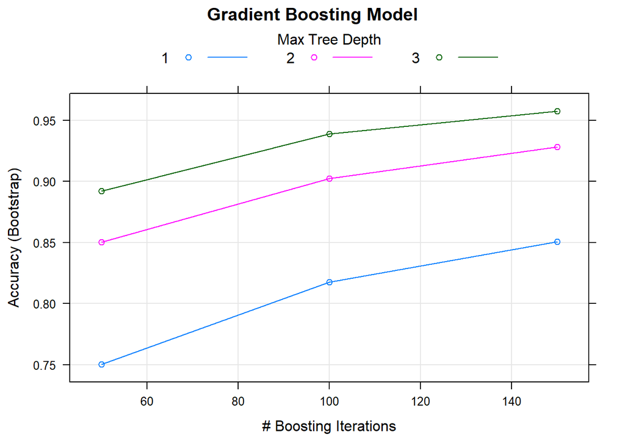

```r
plot(GBMModel, main="Gradient Boosting Model")
```

The accuracy for the final model is 0.957 with 150 trees and depth of 3.

```r
predictTestValGBM = predict(GBMModel, trainingTestVal)
cmGBMTraining = confusionMatrix(trainingTestVal$classe, predictTestValGBM)
cmGBMTraining
```

```
## Confusion Matrix and Statistics
##
##           Reference
## Prediction    A    B    C    D    E
##          A 1656   12    3    2    1
##          B   35 1069   31    1    3
##          C    0   30  976   17    3
##          D    0   11   32  914    7
##          E    5    9    6    9 1053
##
## Overall Statistics
##
##                Accuracy : 0.9631
##                  95% CI : (0.958, 0.9678)
##     No Information Rate : 0.2882
##     P-Value [Acc > NIR] : < 2.2e-16
##
##                   Kappa : 0.9533
##
##  Mcnemar's Test P-Value : 8.048e-05
##
## Statistics by Class:
##
##                      Class: A Class: B Class: C Class: D Class: E
## Sensitivity            0.9764   0.9452   0.9313   0.9692   0.9869
## Specificity            0.9957   0.9853   0.9897   0.9899   0.9940
## Pos Pred Value         0.9892   0.9385   0.9513   0.9481   0.9732
## Neg Pred Value         0.9905   0.9869   0.9852   0.9941   0.9971
## Prevalence             0.2882   0.1922   0.1781   0.1602   0.1813
## Detection Rate         0.2814   0.1816   0.1658   0.1553   0.1789
## Detection Prevalence   0.2845   0.1935   0.1743   0.1638   0.1839
## Balanced Accuracy      0.9861   0.9652   0.9605   0.9796   0.9904
```

## Conclusion

```r
predict(RFModel, testing)
```

```
##  [1] B A B A A E D B A A B C B A E E A B B B
## Levels: A B C D E
```